# gformula model syntax

## Syntax Ideas

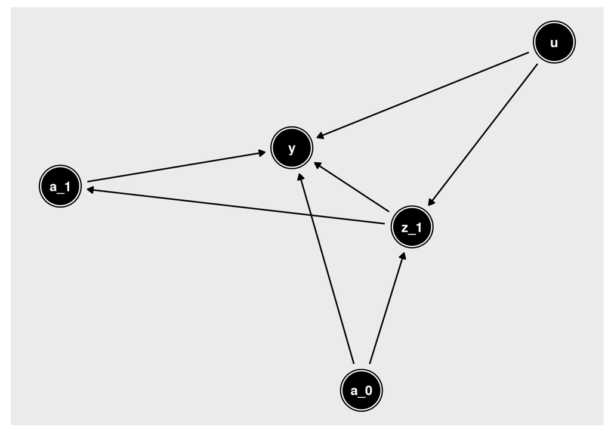

```r
library(ggdag)

dagify(
  z_1 ~ a_0,
  a_1 ~ z_1,
  z_1 ~ u,
  y ~ a_0 + z_1 + a_1 + u
) %>%
  tidy_dagitty() %>%
  ggdag() +
  theme_dag()
```

The `ggdag` formula specification closely follows the model formulas from `Naimi-et-al_example.R`.

```
## Naimi models
z_1 ~ a_0
a_1 ~ z_1
y_2 ~ a_0 + z_1 + a_1 + a_0 * a_1

## or in my proposed formula syntax...

z[[1]] ~ a[[0]]
a ~ z
y[1] ~ a[-1:0] + z + a[-1] * a[0]
```

Why not `y{1}`? Because that’s invalid in R’s formula syntax and we can accept bare formulas if we use `y[1]` instead.

```r
y{1} ~ x
```

```
## Error: <text>:1:2: unexpected '{'
## 1: y{
##      ^
```

Because `x[1]` is valid R syntax, we can reliably capture it in the formula.

```r
y[1] ~ x
```

```
## y[1] ~ x
```

## General syntax overview

1. Single brackets indicate time lag relative to the current time step  
   e.g. `x[1]` is $x_{t_{i + 1}} \;\forall\;t_i \in \lbrace i \colon 0, \dots, N-1 \rbrace$
2. Double brackets indicate an absolute time step  
   e.g. `x[[1]]` is $x_{t_1}$
3. Un-decorated variables represent that variable at the current time step  
   e.g.`x` is $x_{t_{i}} \;\forall\;t_i \in \lbrace i \colon 0, \dots, N-1 \rbrace$
4. If a predictor or outcome is missing at any time step, the model isn’t run

There are a few ways to write the above example models, but they should be equivalent. For example, the `a ~ z` specifies that `a` is predicted by `z` at all time steps (although this would only happen at $t_1$ because `z` is missing otherwise).

The model `z[1] ~ a` specifies that `a` at the current time step predicts `z` at the next time step for all time steps (again in this example this only happens at $t_1$).

Alternatively, the model `z[[1]] ~ a[[0]]` specifes that `a` at $t_0$ predicts `z` at $t_1$, where the time step is indexed absolutely from the inital time step of $t_0$.

## Mixing `[n]` and `[[m]]`

```
z[1] ~ x[[0]] + y
```

for $t \in \lbrace 0, 1, 2 \rbrace$ would result in the models

[output not shown]

## Current time step

For models without `[[`, the models are run at each time step where there are enough leads or lags to fill out the model. If there are observations at three time steps (`0, 1, 2`), then the model

```
y[1] ~ x + y[-1]
```

will only be run at time `t = 1`.

```
y[[2]] ~ x[[0]]
```

## Constraints on time indexes

$t_{\text{outcome}} \geq \max \left( t_{\text{predictors}} \right)$

Models are run from $t_0$ to $t_k$ where $k$ is the maximum value of the index of the *current time step* where at least one model is specified given the input data. In our running example,

```
y[1] ~ a[-1:0] + z + a[-1] * a[0]
```

is only fully specifed at the *current time step* with index $i \geq 1$. In other words, at $t_0$ we don’t have enough observations for the lagged `a` variable. At $t_1$ we have data from $t_0$ and $t_1$ to complete the RHS of the formula and we have data from $t_{1 + 1} = t_2$ to complete the LHS so that we can fit the model.

## From model to MCMC

A problem with relying on missing values at a given time step to inform decisions about model fitting is that this information won’t be available to the MCMC step.

Suppose $Z$ is only measured at $t = 1$ and influences $A$ at $t = 1$, but $A$ was measured at $t = \lbrace 0, 1, 2, 3, \dots \rbrace$. During model building the model `a ~ z` would be fit for $t = 1$ only, given $z$ will contain missing values for all other time steps. But during the simulation phase, a $z$ at time $t = 2$ would be generated and the `a ~ z` model would indicate that `a` should continue to be modelled by `z`.

Instead, we would need to specify the model with absolute time references, i.e.

```
z[[1]] ~ a[[0]]
a[[1]] ~ z[[1]]
a[1] ~ a
```

## Specifying multiple models

The `ggdag::dagify()` syntax is nice in that it lets you specify several models at once,

```r
dagify(
  z_1 ~ a_0,
  a_1 ~ z_1,
  z_1 ~ u,
  y ~ a_0 + z_1 + a_1 + u
)
```

but we quickly run into the issue that the user needs to have more control over the specification of each model and the data that each model accepts.

Each model specification is also attached to several other key pieces of information:

1. The model function, e.g. `glm()` or `lm()`
2. Arguments to the model function, e.g. `family = "binomial"`
3. An expression used to filter data at the current time (or the outcome tim) step, e.g. `value > 0`. The data from the current time step
4. A “callback” function that takes a model created from this process and generates new data

We may be able to abstract key portions of this specification (for example, using “logistic” as a keyword for `glm(..., family = "binomial")`) but the user may want to specify highly specific models at each step and we can definitely allow this.

The final item in the above list would allow the user to specify complex data-generating procedures, and we could also provide a few defaults functions (for example for bi-level models).

The syntax for this function would look like this (using the Naimi example).

```r
gformula() %>%
  model_spec(
    model = z[1] ~ a,
    model_type = "logistic"
  ) %>%
  model_spec(
    model = a ~ z,
    model_type = "logistic"
  ) %>%
  model_spec(
    model = y[1] ~ a[-1:0] + z + a[-1] * a,
    model_type = "linear"
  )
```

And the function signature for `model_spec()` is along these lines

```r
model_spec <- function(
  .gformula = gformula(),
  model,
  model_type = "logistic",
  model_args = NULL,
  generator = NULL
) {
  # set defaults for model_args, e.g.
  if (is.null(model_args) && model_type %in% defined_model_types) {
    model_args <- switch(
      model_type,
      "logistic" = list(family = "binomial")
    )
  }

  # set default data generator
  if (is.null(generator)) {
    generator <- switch(
      model_type,
      "logistic" = gformula::generator_logistic(model),
      "linear"   = gformula::generator_linear(model),
      "bilevel"  = gformula::generator_bilevel(model)
    )
  } else {
    # otherwise generator is user supplied function that takes
    # data and a model object and returns output values for
    # this models outcome. {gformula} would handle providing a flat
    # table at this time step, where we'd use common syntax to track time
    # steps, e.g. y[1] ~ x would hand off data with columns y___01, x___00
    # (which looks crazy but tries to avoid name clashes). Absolute times
    # would, e.g. y[[1]] ~ x[[0]] would be y___T01, x___T00.
    stopifnot(is.function(generator))
  }

  # Add the model specs to the gformula object and return
  .gformula
}
```

## Consistency Requirements for MCMC Step

What checks should we perform ahead of time to ensure that there are enough models to complete the MCMC step? If we removed `a[[1]] ~ z[[1]]` ($a_{t_1} \sim z_{t_1}$) from the example mode, we won’t know how to generate data for $a_{t_1}$ and therefore won’t be able to push data from $t_0$ through to find $y_{t_2}$.

Do we always need bootstrapped data from $t_0$ only, or are there cases where we would need bootstrapped data from several time steps before the data simulation kicks in?